# 120 Lecture 21

Tim Hagemeister

24 October, 2019

## Sample Distros continued

Last time we constructed our first samling distro.

Specifically the sampling distro for xbar (average) with n=2 taken from the dice population.

Important upshot: now we can say something about how likely certain samples are

- Ex: If we roll two dice whats the propbability that the average (xbar) is 3.5?
  - 6/36
- This is boring, but this technique lets us compute probability for sample results.

We need sampling distributions for more practical scenarios. They can be very complicated. But, we actually know a lot about them!

For proportions, Hwere are the importnant facts about the sampling dist:

Center. (E[x])

- Concept: if we take a sample, what do we expect the sample proportion to be?
  - $\mu_\hat{p} = p$
- We expect our sample proportion to be same as our population proportion! this is intuitve but mathematically proveable
  - $\mu$ = expected value of whatever we are looking at
  - $\hat{p}$ = Estimated sample proportion (what percent of you all have black hair )

Spread

- Concept: for proportions, the standard error is:
  - $SE\hat{p} = \sqrt{(p*(1-p)/n))}$
  - Okay so were got math for the center and spread
  - But what about hte shape? what does this distribution actually look like?
  - Amazing fact! as longa s n is large, the sampling distribution always has a normal shape!!! no matter what hte original population is!
  - Central Limit theorem!!!

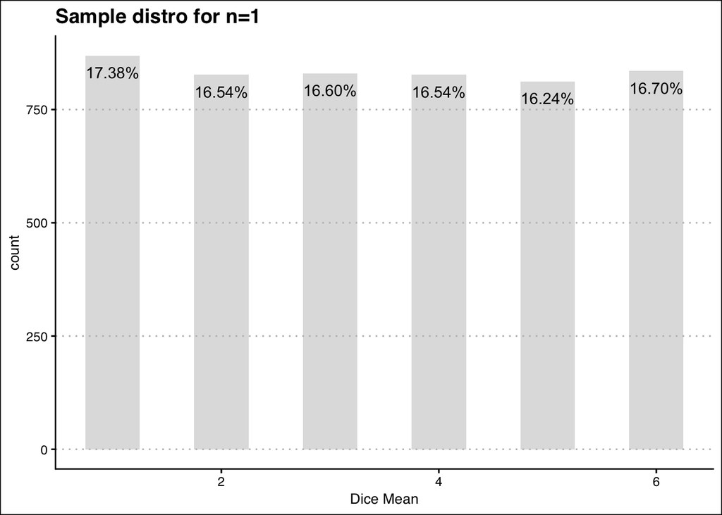

```r
Dice1 <- replicate(5000, mean(sample(1:6, 1, replace=TRUE)))

ggplot() +
  aes(Dice1)+
  geom_histogram(aes(Dice1), binwidth = 0.5 , fill = "gray", alpha = 0.5)+
 geom_text(stat = "count", aes( label = scales::percent(..prop..), vjust = 2))+
  theme_clean()+
  ggtitle("Sample distro for n=1")+
  xlab("Dice Mean")
```

- All we have to do is bump up the sample size to get a normal distribution

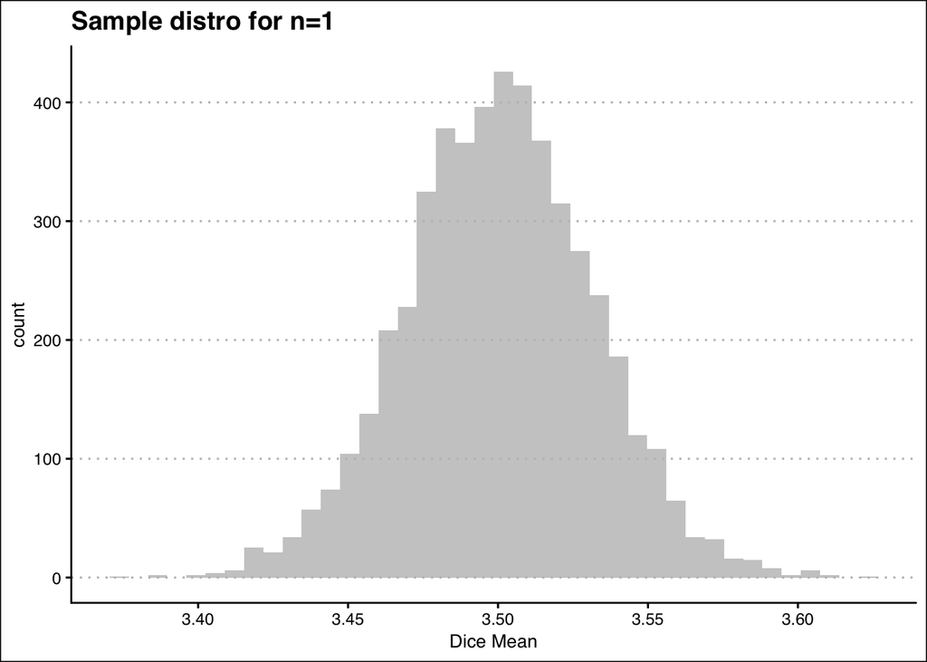

```r
Dice30 <- replicate(5000, mean(sample(1:6, 3000, replace=TRUE)))

ggplot() +
  aes(Dice1)+
  geom_histogram(aes(Dice30), bins = 40 , fill = "gray", alpha = 0.8)+
  theme_clean()+
  ggtitle("Sample distro for n=1")+
  xlab("Dice Mean")
```

- Recap: Thanks to the CLT, We knowt hat our sample distro are always normal as long as n is large (more on large later)
- Practical example: Suppose 20% of DU students hav eblack hair. If we take a sample of 100 DU students, whats the porbability that at least 15% of them have black hair
- Obersvations:
- p = 20% = population proportions (note we only know this becasue i made this up)
- $\hat{p}$ = 15% = Sample population
- n = 100 (trust me this is big enough

We know the distro for $\hat{p}$

- We have a normal distro with mean .2 and SD .04
- All together

```r
 1 - pnorm (.15, .2, .04)
```

```
## [1] 0.8943502
```

Whats the change that less than 30% of the students in the sample have black hair?

```r
pnorm (.30, .2, .04)
```

```
## [1] 0.9937903
```